# Sample EDA

2/8/2018

## Introduction

The objective of this notebook is to understand the sample data better.

Questions:  
* What is the spread of cards who touch on and touch off?  
* By mode?  
* By distance traveled?  
* By geographic distance?  
* Is there any pattern of repeatability of trips?  
* What is the variation of repeat trips?  
* What is the variation on trip durations?  
* For those who take repeat trips, what is the variability of trip durations?

```r
#install.packages('data.table')
library(data.table)
library(tidyverse)
library(skimr)
library(gridExtra)
library(maps)
library(lubridate)
library(hexbin)
library(geosphere)
# library(viridis)
# trans_on_samp <- read_rds("trans_on_samp_4321.rds")
#
# trans_off_samp <- read_rds("trans_off_samp_4321.rds")
trip_len_max_ass <- 3       # Assumed maximum trip length in hours
```

```r
trans_all_samp <- trans_on_samp %>%
  select(CardID, BusinessDate, DateTime, Mode, everything()) %>%
  mutate(transact = "on") %>%
  bind_rows(trans_off_samp %>%
              # select(CardID, BusinessDate, DateTime, Mode, everything()) %>%
              mutate(transact = "off")) %>%
  mutate(RouteID = parse_character(RouteID),
         StopID = parse_character(StopID),
         VehicleID = factor(VehicleID),
         CardType = factor(CardType)) %>%
  glimpse(width = 100)
```

```
Observations: 12,660,814
Variables: 10
$ CardID       <int> 12563380, 1537720, 12972970, 9042130, 4146480, 12158090, 8639260, 13525740...
$ BusinessDate <date> 2015-07-03, 2015-07-03, 2015-07-02, 2015-07-03, 2015-07-01, 2015-07-01, 2...
$ DateTime     <dttm> 2015-07-03 22:56:10, 2015-07-03 17:48:51, 2015-07-02 08:43:23, 2015-07-03...
$ Mode         <int> 2, 2, 2, 1, 1, 1, 3, 3, 3, 1, 1, 1, 2, 3, 2, 2, 2, 1, 1, 1, 1, 1, 3, 2, 2,...
$ CardType     <fct> 1, 1, 1, 0, 2, 2, 0, 1, 70, 2, 1, 1, 1, 1, 0, 0, 1, 0, 9, 1, 1, 1, 65, 9, ...
$ VehicleID    <fct> 0, 0, 0, 460, 2388, 1724, 2221, 391, 687, 2495, 1722, 2945, 0, 642, 0, 0, ...
$ ParentRoute  <chr> "", "", "", "251", "548", "219", "Headless Mode", "Headless Mode", "Headle...
$ RouteID      <chr> "1", "1", "14", "17489", "10574", "17812", "9062", "9062", "9062", "16181"...
$ StopID       <chr> "64404", "64406", "19919", "545", "116", "3798", "24191", "24076", "24003"...
$ transact     <chr> "on", "on", "on", "on", "on", "on", "on", "on", "on", "on", "on", "on", "o...
```

```r
#
# trans_all_samp %>% glimpse()
#
# trans_all_samp %>% str()
```

```r
trans_all_samp %>%
  select(-c(CardID, DateTime)) %>%
  skim()
```

[output not shown]

```r
trans_all_samp %>%
  count(VehicleID, Mode, sort = TRUE)
```

| VehicleID | Mode | n |
| --- | --- | --- |
| 0 | 2 | 7603163 |
| 2720 | 1 | 7507 |
| 2771 | 1 | 7428 |
| 2721 | 1 | 7369 |
| 668 | 3 | 7076 |
| 2722 | 1 | 7069 |
| 692 | 3 | 7023 |
| 689 | 3 | 6911 |
| 672 | 3 | 6901 |
| 683 | 3 | 6800 |

[output cut: 990 more lines]

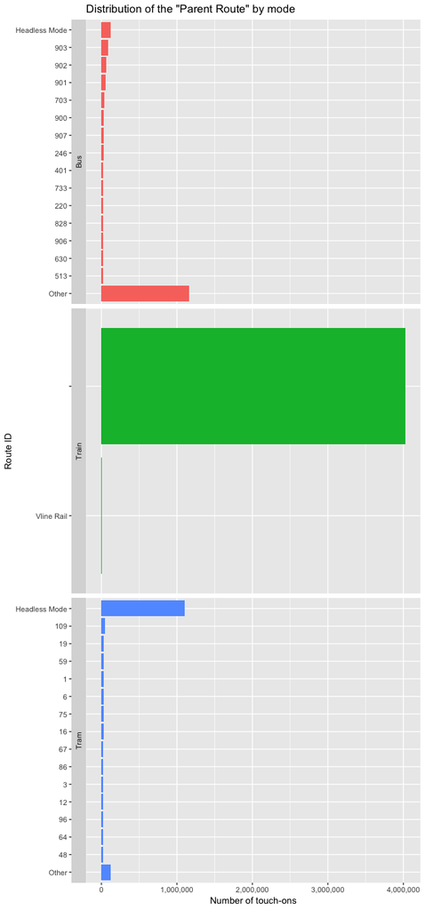

```r
trans_all_samp %>%
  filter(!is.na(ParentRoute),
         transact == "on") %>%
  mutate(Mode = factor(Mode, levels = 1:3, labels = c("Bus", "Train", "Tram"))) %>%
  group_by(Mode) %>%
  mutate(ParentRoute = fct_lump(ParentRoute, n = 15)) %>%
  group_by(ParentRoute, Mode) %>%
  summarise(par_rt_n = n()) %>%
  ggplot(aes(x = fct_relevel(fct_reorder(ParentRoute, par_rt_n), "Other"), y = par_rt_n, fill = Mode)) +
  geom_bar(stat = "identity", show.legend = FALSE) +
  facet_grid(Mode ~ ., scales = "free", switch = "y") +
  coord_flip() +
  scale_y_continuous(labels = scales::comma) +
  labs(title = "Distribution of the \"Parent Route\" by mode",
       x = "Route ID",
       y = "Number of touch-ons")
```

## Spread of cards who touch on and touch off

```r
trip_all <- trans_all_samp %>%
  # slice(1:10000) %>%
  group_by(CardID) %>%
  arrange(CardID, DateTime) %>%
  # str()
  mutate(Mode = factor(Mode, levels = 1:3, labels = c("Bus", "Train", "Tram")),
         DateTime_next = lead(DateTime),
         Mode_next = lead(Mode),
         VehicleID_next = lead(VehicleID),
         RouteID_next = lead(RouteID),
         StopID_next = lead(StopID),
         transact_next = lead(transact),
         trans_intvl_h = (DateTime_next - DateTime) / dhours(1),
         trip_assume = if_else((trans_intvl_h < trip_len_max_ass &
                    transact == "on" & transact_next == "off" &
                    Mode == Mode_next), "on-off", as.character(NA)),
         finyear = year(round_date(BusinessDate + 2, unit = "year")),
         StopID = as.character(StopID)) %>%
# str()
  ungroup() %>%
  glimpse(width = 100)
```

```
Observations: 12,660,814
Variables: 19
$ CardID         <int> 22610, 22610, 22610, 22610, 22610, 22610, 22610, 22610, 22610, 22610, 22...
$ BusinessDate   <date> 2015-08-03, 2015-08-03, 2015-08-03, 2015-08-03, 2015-08-06, 2015-08-06,...
$ DateTime       <dttm> 2015-08-03 12:27:14, 2015-08-03 13:21:30, 2015-08-03 16:05:37, 2015-08-...
$ Mode           <fct> Train, Train, Train, Train, Train, Train, Train, Train, Train, Train, Tr...
$ CardType       <fct> 1, 1, 1, 1, 1, 1, 1, 1, 1, 1, 1, 1, 1, 1, 1, 1, 1, 1, 1, 1, 1, 1, 1, 1, ...
$ VehicleID      <fct> 0, 0, 0, 0, 0, 0, 0, 0, 0, 0, 0, 0, 0, 0, 0, 0, 0, 0, 0, 0, 0, 0, 0, 0, ...
$ ParentRoute    <chr> "", "", "", "", "", "", "", "", "", "", "", "", "", "", "", "", "", "", ...
$ RouteID        <chr> "1", "1", "1", "1", "1", "1", "1", "1", "1", "1", "1", "1", "1", "1", "1...
$ StopID         <chr> "19921", "64403", "64403", "19921", "19921", "64403", "64403", "64402", ...
$ transact       <chr> "on", "off", "on", "off", "on", "off", "on", "off", "on", "on", "off", "...
$ DateTime_next  <dttm> 2015-08-03 13:21:30, 2015-08-03 16:05:37, 2015-08-03 17:07:15, 2015-08-...
$ Mode_next      <fct> Train, Train, Train, Train, Train, Train, Train, Train, Train, Train, Tr...
$ VehicleID_next <fct> 0, 0, 0, 0, 0, 0, 0, 0, 0, 0, 0, 0, 0, 0, 0, 0, 0, 0, 0, 0, 0, 0, 0, 0, ...
$ RouteID_next   <chr> "1", "1", "1", "1", "1", "1", "1", "1", "1", "1", "1", "1", "1", "1", "1...
$ StopID_next    <chr> "64403", "64403", "19921", "19921", "64403", "64403", "64402", "64404", ...
$ transact_next  <chr> "off", "on", "off", "on", "off", "on", "off", "on", "on", "off", "on", "...
$ trans_intvl_h  <dbl> 0.90444444, 2.73527778, 1.02722222, 66.13083333, 1.09944444, 4.63361111,...
$ trip_assume    <chr> "on-off", NA, "on-off", NA, "on-off", NA, "on-off", NA, NA, "on-off", NA...
$ finyear        <dbl> 2016, 2016, 2016, 2016, 2016, 2016, 2016, 2016, 2016, 2016, 2016, 2016, ...
```

OK, the assumed method for classifying a trip seem to hold.  
+ There ones with the shortest intervals involved different stop IDs, different modes or different vehicle IDs.

```r
trip_all %>%
  filter(is.na(trip_assume),
         transact == "on",
         transact_next == "off") %>%
  mutate(trans_intvl_m = round(trans_intvl_h * 60, digits = 1)) %>%
  select(CardID, trans_intvl_m, transact, transact_next, Mode, Mode_next, StopID, StopID_next,
         VehicleID, VehicleID_next, DateTime, DateTime_next) %>%
  arrange(trans_intvl_m)
```

| CardID | trans_intvl_m | transact | transact_next | Mode | Mode_next | StopID | StopID_next | VehicleID | VehicleID_next | DateTime | DateTime_next |
| --- | --- | --- | --- | --- | --- | --- | --- | --- | --- | --- | --- |
| 13755170 | 0.2 | on | off | Train | Bus | 19948 | 20766 | 0 | 3023 | 2017-12-04 19:29:03 | 2017-12-04 19:29:18 |
| 10599360 | 0.3 | on | off | Train | Bus | 20007 | 19236 | 0 | 2878 | 2016-06-20 15:15:56 | 2016-06-20 15:16:14 |
| 1112530 | 0.4 | on | off | Train | Bus | 64404 | 7090 | 0 | 2032 | 2016-04-02 23:47:54 | 2016-04-02 23:48:20 |
| 13448740 | 0.4 | on | off | Train | Tram | 19910 | 20547 | 0 | 366 | 2017-01-17 10:09:25 | 2017-01-17 10:09:52 |
| 16726600 | 0.5 | on | off | Tram | Train | 24117 | 64404 | 206 | 0 | 2016-06-23 16:57:15 | 2016-06-23 16:57:46 |
| 5007800 | 0.6 | on | off | Bus | Train | 19820 | 19888 | 2396 | 0 | 2016-06-23 15:50:20 | 2016-06-23 15:50:54 |
| 13114110 | 0.6 | on | off | Bus | Train | 39765 | 19902 | 2512 | 0 | 2016-09-21 09:38:18 | 2016-09-21 09:38:52 |
| 13596210 | 0.6 | on | off | Bus | Train | 7219 | 19948 | 1719 | 0 | 2015-12-12 07:26:26 | 2015-12-12 07:27:00 |
| 5984630 | 0.8 | on | off | Bus | Train | 45457 | 19888 | 3003 | 0 | 2016-08-31 14:33:05 | 2016-08-31 14:33:53 |
| 13676910 | 0.8 | on | off | Train | Bus | 19933 | 115 | 0 | 981 | 2017-09-25 16:48:46 | 2017-09-25 16:49:33 |

[output cut: 990 more lines]

### Variation in the trip durations

Trip journey durations have been consistent over the survey horizon.

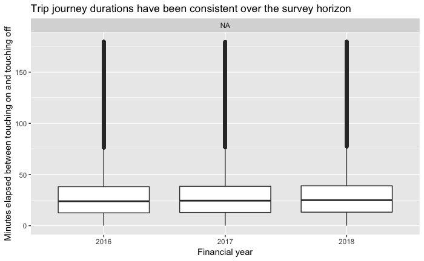

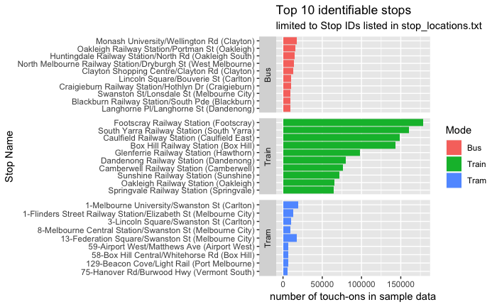

```r
trip_all %>%
  # filter(StopID < 60000) %>%
  group_by(Mode, StopID) %>%
  summarise(StopID_n = n()) %>%
  inner_join(stop_locs_raw %>% select(StopLocationID, StopNameLong, StopType),
             by = c("StopID" = "StopLocationID")) %>%
  top_n(., 10, StopID_n) %>%
  select(Mode, StopID, StopNameLong, StopType, StopID_n) %>%
  ungroup() %>%
  arrange(Mode, -StopID_n) %>%
  # ungroup() %>%
  ggplot(aes(x = fct_reorder(StopNameLong, StopID_n) , y = StopID_n, fill = Mode)) +
  geom_bar(stat = "identity") +
  coord_flip() +
  facet_grid(Mode ~ ., scales = "free_y", switch = "y") +
  labs(title = "Top 10 identifiable stops",
       subtitle = "limited to Stop IDs listed in stop_locations.txt",
       y = "number of touch-ons in sample data",
       x = "Stop Name")
```

The majority of StopID for Mode 3 (trams) don’t seem to have a join in stop_locations.txt.

My inference is that the tram data is limited.

```r
trip_all %>%
  filter(StopID < 60000,
         Mode == "Tram") %>%
  group_by(Mode, StopID) %>%
  summarise(StopID_n = n()) %>%
  arrange(Mode, -StopID_n) %>%
  left_join(stop_locs_raw %>% select(StopLocationID, StopNameLong, StopType),
             by = c("StopID" = "StopLocationID")) %>%
  top_n(., 300, StopID_n) %>%
  # select(Mode, StopID, StopNameLong, StopType, StopID_n)
  count(StopType, sort = TRUE)
```

| Mode | StopType | n |
| --- | --- | --- |
| Tram | NA | 187 |
| Tram | Platform | 81 |
| Tram | Safety Zone | 20 |
| Tram | Kerbside | 12 |

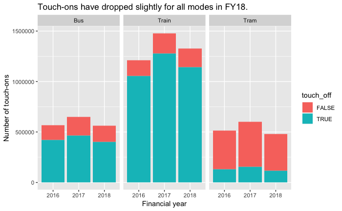

```r
trip_all %>%
  ungroup() %>%
  filter(transact == "on") %>%
  mutate(finyear = factor(year(round_date(BusinessDate + 2, unit = "year"))),
         # Mode = factor(Mode, levels = 1:3, labels = c("Bus", "Train", "Tram")),
         touch_off = !is.na(trip_assume),
         trans_intvl_m = trans_intvl_h * 60) %>%
  select(Mode, CardType, trans_intvl_m, trip_assume, finyear, touch_off) %>%
  ggplot(., aes(x = finyear, fill = touch_off)) +
  geom_bar() +
  facet_wrap(. ~ Mode) +
  labs(title = "Touch-ons have dropped slightly for all modes in FY18.",
       # subtitle = "Tram customers are much less likely to touch-off compared to other modes",
       x = "Financial year",
       y = "Number of touch-ons")
```

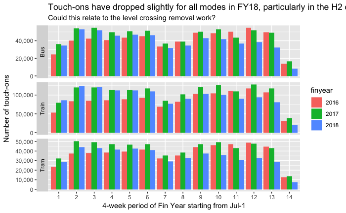

```r
trip_all %>%
  ungroup() %>%
  # slice(., 1:200) %>%
  filter(transact == "on") %>%
  mutate(finyear = factor(year(round_date(BusinessDate + 2, unit = "year"))),
         # Mode = factor(Mode, levels = 1:3, labels = c("Bus", "Train", "Tram")),
         month_abbr = factor(month(BusinessDate, label = TRUE),
                            levels = c("Jul", "Aug", "Sep", "Oct", "Nov", "Dec", "Jan", "Feb", "Mar", "Apr", "May", "Jun")),
         week_grp = factor(((week(BusinessDate + 2 + 182)) %/% 4) + 1),
         BusDate_6m = BusinessDate + 2 + 182,
         touch_off = !is.na(trip_assume),
         trans_intvl_m = trans_intvl_h * 60) %>%
  select(Mode, CardType, trans_intvl_m, trip_assume, finyear, touch_off, month_abbr, BusinessDate, week_grp, BusDate_6m) %>%
  ggplot(., aes(fill = finyear, x = week_grp)) +
  geom_bar(position = "dodge") +
  scale_y_continuous(labels = scales::comma) +
  facet_grid(Mode ~ ., scales = "free_y", switch = "y") +
  labs(title = "Touch-ons have dropped slightly for all modes in FY18, particularly in the H2 of FY",
       subtitle = "Could this relate to the level crossing removal work?",
       x = "4-week period of Fin Year starting from Jul-1",
       y = "Number of touch-ons")
```

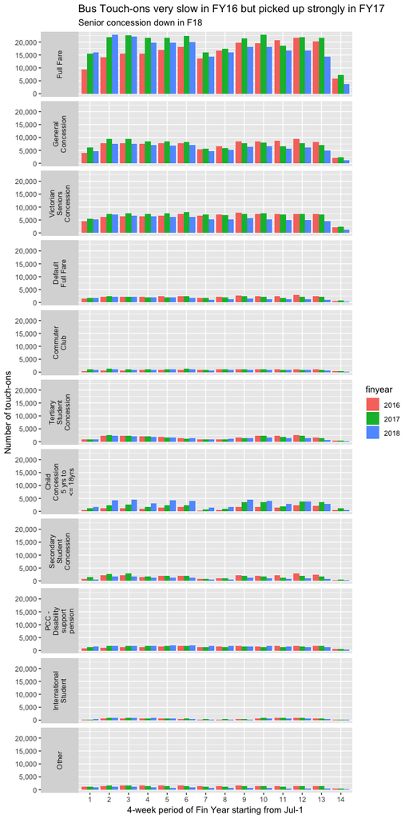

```r
chrt_mnthly_mode <- function(pmode = "Bus", ptitle = "", psubtitle = "") {
  trip_all %>%
  ungroup() %>%
  # slice(., 1:200) %>%
  filter(transact == "on") %>%
  left_join(card_type_raw %>% select(Card_SubType_ID, Card_SubType_Desc) %>% mutate(Card_SubType_ID = factor(Card_SubType_ID)),
            by = c("CardType" = "Card_SubType_ID")) %>%
  mutate(finyear = factor(year(round_date(BusinessDate + 2, unit = "year"))),
         # Mode = factor(Mode, levels = 1:3, labels = c("Bus", "Train", "Tram")),
         month_abbr = factor(month(BusinessDate, label = TRUE),
                            levels = c("Jul", "Aug", "Sep", "Oct", "Nov", "Dec", "Jan", "Feb", "Mar", "Apr", "May", "Jun")),
         week_grp = factor(((week(BusinessDate + 2 + 182)) %/% 4) + 1),
         BusDate_6m = BusinessDate + 2 + 182,
         touch_off = !is.na(trip_assume),
         trans_intvl_m = trans_intvl_h * 60,
         card_type_grp = fct_lump(Card_SubType_Desc, 10) %>% fct_infreq() %>% fct_relevel(., "Other", after = Inf)) %>%
  select(Mode, card_type_grp, CardType, trans_intvl_m, trip_assume, finyear, touch_off, month_abbr, BusinessDate, week_grp, BusDate_6m) %>%

  filter(Mode == pmode) %>%

  ggplot(., aes(fill = finyear, x = week_grp)) +
  geom_bar(position = "dodge") +
  scale_y_continuous(labels = scales::comma) +
  facet_grid(card_type_grp ~ ., switch = "y", labeller = labeller(card_type_grp = label_wrap_gen(10))) +
  labs(title = ptitle,
       subtitle = psubtitle,
       x = "4-week period of Fin Year starting from Jul-1",
       y = "Number of touch-ons")
}
chrt_mnthly_mode("Bus",
                 "Bus Touch-ons very slow in FY16 but picked up strongly in FY17",
                 "Senior concession down in F18")
```

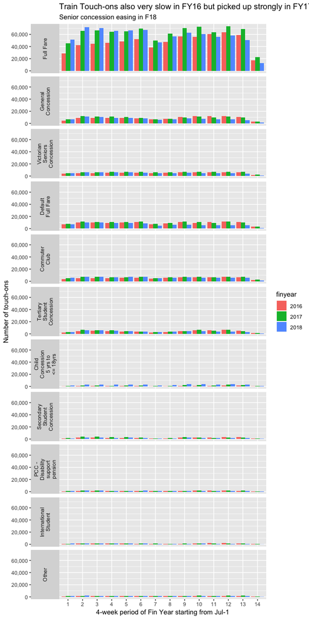

```r
chrt_mnthly_mode("Train",
                 "Train Touch-ons also very slow in FY16 but picked up strongly in FY17",
                 "Senior concession easing in F18")
```

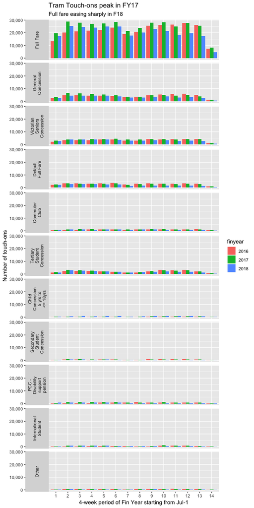

```r
chrt_mnthly_mode("Tram",
                 "Tram Touch-ons peak in FY17",
                 "Full fare easing sharply in F18")
```

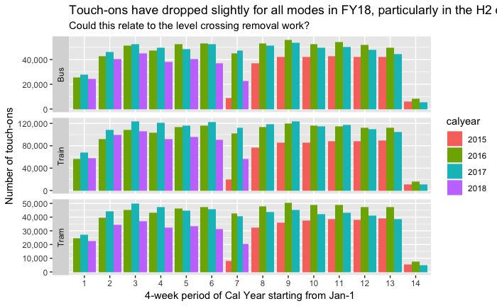

```r
trip_all %>%
  ungroup() %>%
  # slice(., 1:200) %>%
  filter(transact == "on") %>%
  mutate(finyear = factor(year(round_date(BusinessDate + 2, unit = "year"))),
         calyear = factor(year(BusinessDate)),
         # Mode = factor(Mode, levels = 1:3, labels = c("Bus", "Train", "Tram")),
         month_abbr = factor(month(BusinessDate, label = TRUE),
                            levels = c("Jul", "Aug", "Sep", "Oct", "Nov", "Dec", "Jan", "Feb", "Mar", "Apr", "May", "Jun")),
         week_grp = factor((week(BusinessDate) %/% 4) + 1),
         BusDate_6m = BusinessDate + 2 + 182,
         touch_off = !is.na(trip_assume),
         trans_intvl_m = trans_intvl_h * 60) %>%
  select(Mode, CardType, trans_intvl_m, trip_assume, calyear, touch_off, month_abbr, BusinessDate, week_grp, BusDate_6m) %>%
  ggplot(., aes(fill = calyear, x = week_grp)) +
  geom_bar(position = "dodge") +
  scale_y_continuous(labels = scales::comma) +
  facet_grid(Mode ~ ., scales = "free_y", switch = "y") +
  labs(title = "Touch-ons have dropped slightly for all modes in FY18, particularly in the H2 of FY",
       subtitle = "Could this relate to the level crossing removal work?",
       x = "4-week period of Cal Year starting from Jan-1",
       y = "Number of touch-ons")
```

## Review of Distance Travelled.

Will limit this analysis to buses and trains due to the very limited nature of tram data.

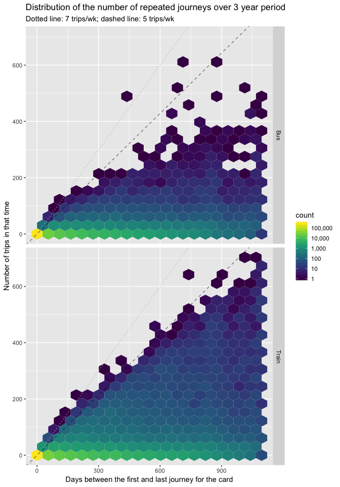

```r
my_breaks <- c(1, 10, 100, 1000, 10000, 10^5, 10^6)
trip_all %>%
  ungroup() %>%
  # slice(1:10000) %>%
  filter(!is.na(trip_assume),
         Mode != "Tram") %>%
  group_by(CardID, Mode, StopID, StopID_next) %>%
  summarise(trips = n(),
            bus_date_from = min(BusinessDate, na.rm = TRUE),
            bus_date_to = max(BusinessDate, na.rm = TRUE)) %>%
  group_by(CardID) %>%
  mutate(trips_sh = trips / sum(trips),
         bus_date_range = (bus_date_to - bus_date_from) / ddays(1)) %>%
  # arrange(CardID, -trips)
  ggplot(aes(x = bus_date_range, y = trips)) +
  geom_hex(bins = 20) +
  geom_abline(aes(intercept = 0, slope = 1), linetype = 3, colour = "grey") +
  geom_abline(aes(intercept = 0, slope = 5/7), linetype = 2, alpha = 0.5) +
  viridis::scale_fill_viridis(name = "count", trans = "log",
                      breaks = my_breaks, labels = scales::comma(my_breaks)) +
  labs(title = "Distribution of the number of repeated journeys over 3 year period",
       subtitle = "Dotted line: 7 trips/wk; dashed line: 5 trips/wk",
       x = "Days between the first and last journey for the card",
       y = "Number of trips in that time") +
  facet_grid(Mode ~ .)
```

```r
NA
```

### Calculate distance travelled

Will use the geosphere package to calculate distances.

```r
trip_jrnys <-
  trip_all %>%
  ungroup() %>%
  filter(!is.na(trip_assume),
         Mode != 3) %>%
  mutate(finyear = factor(year(round_date(BusinessDate + 2, unit = "year"))),
         Mode = factor(Mode, levels = 1:3, labels = c("Bus", "Train", "Tram"))) %>%
  inner_join(stop_locs_raw %>% select(StopLocationID, GPSLat, GPSLong, SuburbName),
             by = c("StopID" = "StopLocationID")) %>%
  rename(lat_from = GPSLat, lon_from = GPSLong, suburb_from = SuburbName) %>%
  inner_join(stop_locs_raw %>% select(StopLocationID, GPSLat, GPSLong, SuburbName),
             by = c("StopID_next" = "StopLocationID")) %>%
  rename(lat_to = GPSLat, lon_to = GPSLong, suburb_to = SuburbName) %>%
  mutate(trip_dist = distHaversine(cbind(lon_from, lat_from), cbind(lon_to, lat_to))) %>%
  glimpse(width = 100)
```

```
Observations: 2,206,398
Variables: 26
$ CardID         <int> 17970, 17970, 17970, 17970, 17970, 17970, 17970, 21110, 21110, 21110, 21...
$ BusinessDate   <date> 2015-07-28, 2015-07-31, 2015-08-03, 2015-08-03, 2015-08-04, 2015-08-05,...
$ DateTime       <dttm> 2015-07-28 08:02:35, 2015-07-31 12:00:54, 2015-08-03 08:03:59, 2015-08-...
$ Mode           <fct> NA, NA, NA, NA, NA, NA, NA, NA, NA, NA, NA, NA, NA, NA, NA, NA, NA, NA, ...
$ CardType       <fct> 1, 1, 1, 1, 1, 1, 1, 1, 1, 1, 1, 1, 1, 1, 1, 1, 1, 1, 1, 1, 1, 1, 1, 1, ...
$ VehicleID      <fct> 0, 0, 0, 0, 0, 0, 0, 2762, 0, 1164, 1294, 2574, 1294, 0, 1294, 1307, 276...
$ ParentRoute    <chr> "", "", "", "", "", "", "", "695", "", "798", "Headless Mode", "695", "6...
$ RouteID        <chr> "14", "14", "14", "13", "14", "14", "13", "16905", "14", "17777", "9044"...
$ StopID         <chr> "19959", "19959", "19959", "19911", "19959", "19959", "19911", "13853", ...
$ transact       <chr> "on", "on", "on", "on", "on", "on", "on", "on", "on", "on", "on", "on", ...
$ DateTime_next  <dttm> 2015-07-28 08:27:29, 2015-07-31 12:19:16, 2015-08-03 08:26:58, 2015-08-...
$ Mode_next      <fct> Train, Train, Train, Train, Train, Train, Train, Bus, Train, Bus, Bus, B...
$ VehicleID_next <fct> 0, 0, 0, 0, 0, 0, 0, 2762, 0, 1164, 1294, 2574, 1294, 0, 1294, 1307, 276...
$ RouteID_next   <chr> "13", "13", "13", "14", "13", "13", "14", "16905", "14", "17777", "9044"...
$ StopID_next    <chr> "19911", "19911", "19911", "19959", "19911", "19911", "19959", "13842", ...
$ transact_next  <chr> "off", "off", "off", "off", "off", "off", "off", "off", "off", "off", "o...
$ trans_intvl_h  <dbl> 0.41500000, 0.30611111, 0.38305556, 0.37972222, 0.50916667, 0.47361111, ...
$ trip_assume    <chr> "on-off", "on-off", "on-off", "on-off", "on-off", "on-off", "on-off", "o...
$ finyear        <fct> 2016, 2016, 2016, 2016, 2016, 2016, 2016, 2016, 2016, 2016, 2016, 2016, ...
$ lat_from       <dbl> -37.83845, -37.83845, -37.83845, -37.84937, -37.83845, -37.83845, -37.84...
$ lon_from       <dbl> 144.9923, 144.9923, 144.9923, 145.0417, 144.9923, 144.9923, 145.0417, 14...
$ suburb_from    <chr> "South Yarra", "South Yarra", "South Yarra", "Malvern", "South Yarra", "...
$ lat_to         <dbl> -37.84937, -37.84937, -37.84937, -37.83845, -37.84937, -37.84937, -37.83...
$ lon_to         <dbl> 145.0417, 145.0417, 145.0417, 144.9923, 145.0417, 145.0417, 144.9923, 14...
$ suburb_to      <chr> "Malvern", "Malvern", "Malvern", "South Yarra", "Malvern", "Malvern", "S...
$ trip_dist      <dbl> 4509.111, 4509.111, 4509.111, 4509.111, 4509.111, 4509.111, 4509.111, 69...
```

What is the spread of distances by year and mode?

[figure not shown]

```r
trip_jrnys %>%
  select(finyear, Mode, trip_dist) %>%
  filter(trip_dist >= 1) %>%
  ggplot(aes(x = finyear, y = trip_dist)) +
  geom_boxplot() +
  scale_y_log10(breaks = c(map_dbl(0:5, ~ 10 ^ .x)), labels = scales::comma) +
  facet_grid(Mode ~ .) +
  labs(title = "Travel distances have remained steady over the 3 years",
       subtitle = "There are significant short distances for bus travel",
       x = "Financial year",
       y = "Distance between start and end in metres")
```

### Transactions by Card Type

```r
trip_all %>%
  mutate(CardType = as.character(CardType)) %>%
  left_join(card_type_raw %>% select(Card_SubType_ID, Card_SubType_Desc),
            by = c("CardType" = "Card_SubType_ID")) %>%
  glimpse()
```

[output not shown]

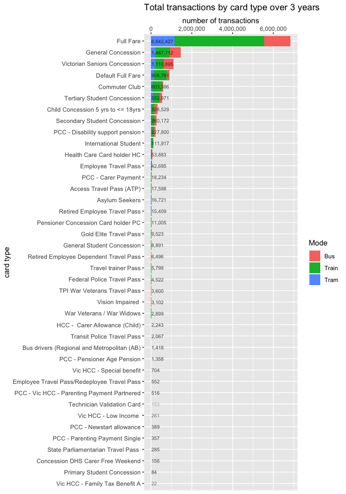

```r
trip_all %>%
  # slice(1:10000) %>%
  mutate(CardType = as.character(CardType)) %>%
  left_join(card_type_raw %>% select(Card_SubType_ID, Card_SubType_Desc),
            by = c("CardType" = "Card_SubType_ID")) %>%
  group_by(Card_SubType_Desc) %>%
  mutate(card_type_n = n()) %>%
  group_by(Card_SubType_Desc, card_type_n, Mode) %>%
  summarise(trans_n = n()) %>%
  ungroup() %>%
  ggplot(aes(x = reorder(Card_SubType_Desc, trans_n), fill = Mode, y = trans_n)) +
  geom_bar(stat = "identity") +
  geom_text(aes(label = scales::comma(card_type_n), hjust = 0, y = 10000), size = 2.5, alpha = 0.3, nudge_y = 10000) +
  scale_y_continuous(labels = scales::comma, position = "right") +
  labs(title = "Total transactions by card type over 3 years",
       y = "number of transactions",
       x = "card type") +
  coord_flip()
```

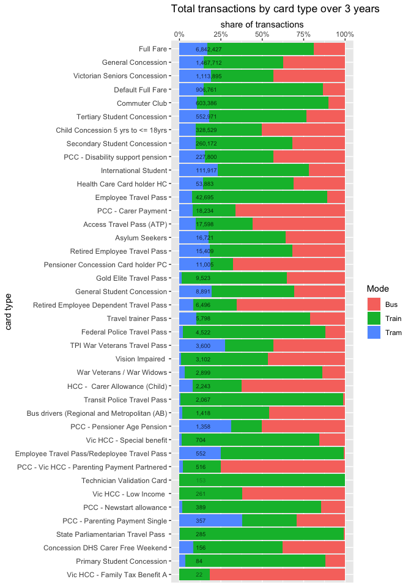

```r
trip_all %>%
  # slice(1:10000) %>%
  mutate(CardType = as.character(CardType)) %>%
  left_join(card_type_raw %>% select(Card_SubType_ID, Card_SubType_Desc),
            by = c("CardType" = "Card_SubType_ID")) %>%
  group_by(Card_SubType_Desc) %>%
  mutate(card_type_n = n()) %>%
  group_by(Card_SubType_Desc, card_type_n, Mode) %>%
  summarise(trans_n = n()) %>%
  ungroup() %>%
  ggplot(aes(x = reorder(Card_SubType_Desc, trans_n), fill = Mode, y = trans_n)) +
  geom_bar(stat = "identity", position = "fill") +
  geom_text(aes(label = scales::comma(card_type_n), hjust = 0, y = 0.1), size = 2.5, alpha = 0.3) +
  scale_y_continuous(labels = scales::percent, position = "right") +
  labs(title = "Total transactions by card type over 3 years",
       y = "share of transactions",
       x = "card type") +
  coord_flip()
```

```r
trip_all %>%
  filter(!is.na(trip_assume),
         Mode != "Tram") %>%
  group_by(CardType) %>%
  mutate(card_type_n = n()) %>%
  ungroup() %>%
  # slice(1:100000) %>%
  mutate(finyear = factor(year(round_date(BusinessDate + 2, unit = "year"))),
         StopID = parse_integer(StopID),
         CardType = as.character(CardType)) %>%
  inner_join(stop_locs_raw %>% select(StopLocationID, GPSLat, GPSLong, SuburbName),
             by = c("StopID" = "StopLocationID")) %>%
  rename(lat_from = GPSLat, lon_from = GPSLong, suburb_from = SuburbName) %>%
  inner_join(stop_locs_raw %>% select(StopLocationID, GPSLat, GPSLong, SuburbName),
             by = c("StopID_next" = "StopLocationID")) %>%
  rename(lat_to = GPSLat, lon_to = GPSLong, suburb_to = SuburbName) %>%
  mutate(trip_dist = distHaversine(cbind(lon_from, lat_from), cbind(lon_to, lat_to)) / 10^3) %>%
  filter(trip_dist > 0) %>%
  left_join(card_type_raw %>% select(Card_SubType_ID, Card_SubType_Desc),
            by = c("CardType" = "Card_SubType_ID")) %>%
  ggplot(aes(x = fct_reorder(Card_SubType_Desc, card_type_n), y = trip_dist, colour = Mode)) +
  geom_boxplot(outlier.size = 1, show.legend = FALSE) +
  facet_grid(. ~ Mode, scales = "free_y") +
  labs(title = "Range of distances travelled",
       subtitle = "Trams excluded due to incomplete trip information",
       y = "Distance in km",
       x = "Card type") +
  scale_y_log10(breaks = 10 ^ (-1:2)) +
  coord_flip()
```

[output not shown]

```
Error in inner_join_impl(x, y, by_x, by_y, aux_x, aux_y, na_matches) :
  Can't join on 'StopID' x 'StopLocationID' because of incompatible types (integer / character)
```